# Programming for Data Science 2024

## Homework Assigment Three

Homework Assigment Three focus in the step-by-step implementation of a simple, yet popular, clustering algorithm, the K-Means. Although in most projects you will source algorithms from libraries such as scikit-learn or Keras, in other cases you will need to implement an algorithm yourself. For instance, if such algorithm is not available or if you want to tailor the algorithm to your problem. In that sense, learning to implement algorithms is an important part of your skillset.

This is an Individual assingment, students that are caught cheating will obtain a score of 0 points.  
The Homeworking Assignment Three is worth 10% of your final grade.

The submission package should correspond to a .zip archive (.rar files are not acceptable) with the following files:

1. Jupyter Notebook with the output of all the cells;
2. HTML print of your Jupyter Notebook;
3. All files outputed as part of the exercises.

The .zip archive filename should be student1ID_student2ID.

Your submission will be graded according to the following guidelines:

1. Execution (does your program does what is asked from the exercise?)
2. Objectivity (are you using the adequate libraries?)
3. Readibility of your code (that includes comments, naming of variables, supporting text, etc ...)

In some questions might require that you make critical decisions, or design choices. In such cases, you will be graded according also for your ability to justify and support your decisions.

**Comment your code properly, which includes naming your variables in a meaningful manner. Badly documented code will be penalized.**

Submission is done through the respective Moodle activity. Deadline is November 2nd at 12:00. A penality of 1 point per day late will be applied to late deliveries, with a maximum of 5 days.

Please fill the following fields:  
**Name**: André Filipe Gomes Silvestre  
**ID**: 20240502

**Name**: Umeima Adam Mahomed  
**ID**: 20240543

## Clustering with K-Means

K-Means is one of the most popular "clustering" algorithms, which you perhaps are already familiar from the Data Mining curricular unit. K-means estimates the location of $k$ centroids that it uses to define clusters. A point is considered to be in a particular cluster if it is closer to that cluster's centroid than any other centroid.

The K-means Algorithm consists in an iterative process that is roughly as follows:

1. Choose value for K (number of clusters);
2. Initialize the locations of the centroids, which we can do by randomly select K points from your dataset as initial locations of the centroids;
3. Calculate distance of all other points to each of the K centroids;
4. Associate each point to the cluster of the closest centroid;
5. Update the centroid position, by computing the average coordinates of all points associated to each cluster;
6. Evaluate the average change in the centroids positions, as a measure of convergence (the algorithm is said to have converged to the solution when the positions of the centroids don't change more than a given tolerance threshold);
7. Repeat steps 3-6 until either the centroids no longer move more than a tolerance threshold or until you repeated these steps at least for specified number of iterations (niter)

The algorithm is thus parametized by the number of clusters (K), the maximum number of iterations (niter), and the tolerance threshold (tol).

### Step 1

Let us start by importing the necessary libraries to execute this homework.  
Import numpy, Scipy, and pandas using, respectively, the aliases np, sc, and pd.

```python
# Import libraries
import numpy as np
import scipy as sc
import pandas as pd

# Set the seed for reproducibility purposes
np.random.seed(2024)
```

It is important that we devise a strategy to test our code at each step, in order to assess if it performs as expected. To that end, we have split each step of the algorithm into different blocks, and we ask you to test each block against a simple scenario where the outcome is predictable and can be computed by hand. In some steps, however, we want to pass a more comprehensive dataset with similar properties to the real dataset that we will be working with.

Such, test datasets try to create realistic conditions in which your algorithm is expected to work correctly, and for which we can also assess if the solution matches our expectation. This allows us to have a general understanding if the algorithm performs as expected in "real-world" conditions.

For this homework we will resort to a dataset that contains two clearly distinct clusters. We generated the clusters by sampling points from two distinct gaussian distributions with different averages and same standard deviation.  
As such, our algorithm should be able to identify each cluster easily, and place the centroids close to the averages of the two distributions.

Run the cell below to download, load the data into a numpy array, and visualize your Test dataset.  
You will run your algorithm implementation against this dataset as a proof of work.

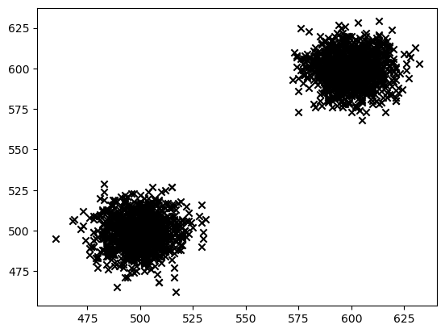

```python
import matplotlib.pyplot as plt

# Download the file into a dataframes and convert it to a numpy array.
data_test = pd.read_csv("https://www.dropbox.com/s/gax1l68jsarxqt9/data_test.txt?dl=1", header=None).to_numpy()

# Plot the points into a scatter plot
plt.scatter(data_test[:, 0], data_test[:,1], color ='k', marker='x');
```

```python
# Check the shape of the data
print(data_test.shape)
```

```
(2047, 2)
```

```python
# Check the first 5 rows of the data
print(data_test[:5])
```

```
[[502 505]
 [504 489]
 [515 514]
 [496 498]
 [505 501]]
```

**Optional Challenge:** Can you write a function that generates an artificial dataset for testing purposes?  
We will award one extra point for students that offer a good implementation.

**Consider leaving this challenge to the very end of the assignment**

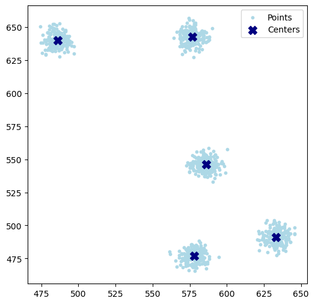

```python
# ----------------- Optional Challenge -----------------
# Function that generates an artificial dataset for testing purposes
def generate_data(n_points, n_clusters, n_features, min_value=450, max_value=650, center_std_dev=5):
    """Function that generates an artificial dataset for testing purposes

    Args:
        n_points (int): Number of points to generate     (Number of samples)
        n_clusters (int): Number of clusters to generate (Number of classes)
        n_features (int): Number of features to generate (Dimensionality of the data)
        min_value (int): Minimum value for the centers of the clusters (Default: 450)
        max_value (int): Maximum value for the centers of the clusters (Default: 650)
        center_std_dev (int): Standard deviation for the centers of the clusters (Default: 5)
    Returns:
        data (np.array): Array with the generated points
        centers (np.array): Array with the centers of the clusters
    """

    # Generate random centers [Minimum value default: 450, Maximum value default: 650 - Based on the data_test]
    centers = np.random.randint(min_value, max_value, size=(n_clusters, n_features))

    # Initialize an empty list to store the points
    data = []

    # Generate points around each center using normal distribution
    for center in centers:
        cluster_points = np.random.normal(loc=center, scale=center_std_dev, size=(n_points // n_clusters, n_features))
        data.append(cluster_points)

    # Combine all points into a single array
    data = np.vstack(data)

    return data, centers

# Generate a dataset with 1000 points, 5 clusters and 2 features
data_gen, centers_gen = generate_data(1000, 5, 2)

# Plot the points into a scatter plot
plt.figure(figsize=(6, 6))
plt.scatter(data_gen[:, 0], data_gen[:,1], marker='o', c='lightblue', label='Points', s=10)
plt.scatter(centers_gen[:, 0], centers_gen[:,1], c='navy', s=100, marker='X', label='Centers')
plt.legend();
```

```python
# ------------------------ Check if the function works as expected ------------------------
# Return the minimum and maximum values of the dataset
print("Minimum and Maximum values of the dataset: ",
      data_gen[:, 0].min(), data_gen[:,0].max(),
      data_gen[:,1].min(), data_gen[:,1].max())
data_gen[:5], centers_gen # Print the 5th row of the dataset and the 5th label and the centers
```

```
Minimum and Maximum values of the dataset:  474.5557945447907 645.7411564394724 465.4415919444636 656.8084721203173
```

```
(array([[591.99589486, 550.34435063],
        [585.80678564, 553.63197434],
        [578.72191936, 538.74745259],
        [584.36288463, 552.22962647],
        [582.52854014, 541.99752764]]),
 array([[586, 546],
        [578, 477],
        [486, 640],
        [633, 491],
        [577, 643]]))
```

### Step 2

Write a function named **init** that takes two arguments: $points$ and $K$.  
The function **init** should return a numpy ndarray with $K$ elements sampled randomly and without replacement from $points$. Meaning, the same point cannot picked up twice.

**Show that your function performs as desired by calling it with** $K = 2$ **and use data_test as the** $points$

```python
# Function  that initializes the centroids of the K-means algorithm
def init(points: np.array, K: int) -> np.array:
    """Function that initializes the centroids of the K-means algorithm

    Args:
        points (np.array): Array with the data points
        K (int): Number of centroids to generate

    Returns:
        generated_points (np.array): Array with the generated centroids
    """
    # Generate numpy array with K elements sampled randomly and without replacement from points that is a 2D numpy array
    # We will use the np.random.choice function to generate the indexes of the points that will be used as centroids.
    # Source: https://numpy.org/doc/stable/reference/random/generated/numpy.random.choice.html
    indexes = np.random.choice(points.shape[0], K, replace=False)
    generated_points = points[indexes]

    # Return the generated points
    return generated_points

# Test the function with the data_test and K=2
print('Initial centroids:\n', init(data_test, 2))
```

```
Initial centroids:
 [[492 495]
 [516 509]]
```

### Step 3

Write a function named **distance** that takes two arguments: $p1$ and $p2$.  
The function **distance** should return a scalar that corresponds to the euclidean distance between points $p1$ and $p2$, that should have a ndarray format.  
Assume that $p1$ and $p2$ are two ndarrays of the same size.

Recall that the euclidian distance (d) between two points ($p_1$ and $p_2$) in a 2-dimensional space is given by:  
\begin{equation} d(p_1, p_2) = \sqrt{(x_1-x_2)^2 + (y_1-y_2)^2 } \end{equation}  
where $p_1 = \{x_1,y_1\}$ and $p_2 = \{x_2,y_2\}$.

**1) Test that your function works by computing the distance between p1=(1,3) and p2=(7,2), which is $\approx$ 6.08.**  
**Consider using the existing Numpy or Scipy packages for this task.**

Can you write a function that computes the euclidean distance between two points of arbitrary dimension?  
In general, for arbitrary dimensionality the square of the distance can be computed as:  
\begin{equation} d^2(p_1, p_2) = \sum_{i=0}^{D-1} (x_i-y_i)^2 \end{equation}  
where $p_1 = \{x_1,x_2,...,x_{D-1}, x_D\}$ and $p_2 = \{y_1,y_2,...,y_{D-1},y_D\}$.

**2) Show that your function works by computing the distance between (1,3,-9,12) and (7,2,0,5)**

***1)***

```python
# Function to calculate the Euclidean distance between two points 'p1' and 'p2'
def distance(p1: np.array, p2: np.array) -> float:
    """Function to calculate the Euclidean distance between two points 'p1' and 'p2'

    Args:
        p1 (np.array): First point
        p2 (np.array): Second point

    Returns:
        distance (float): Euclidean distance between the two points
    """
    # Calculate the squared difference between the two points (p1 and p2)
    squared_diff = (p1 - p2) ** 2

    # Calculate the sum of the squared differences
    sum_squared_diff = np.sum(squared_diff)

    # Calculate the square root of the sum of the squared differences
    distance = np.sqrt(sum_squared_diff)

    # # ------------------------------------ [Alternative] ------------------------------------
    # # Calculate the Euclidean distance using a built-in function from scipy
    # # Source: https://docs.scipy.org/doc/scipy/reference/generated/scipy.spatial.distance.euclidean.html
    # distance = sc.spatial.distance.euclidean(p1, p2)

    # Return the distance
    return distance
```

```python
# Test variables, do not change the values
p1 = np.array([1,3])
p2 = np.array([7,2])
```

```python
# Test the function with the test variables
print("Distance (1,3) -> (7,2):", round(distance(p1, p2),2))
```

```
Distance (1,3) -> (7,2): 6.08
```

***2)***

```python
# Test variables, do not change the values
p1 = np.array([1,3,-9,12])
p2 = np.array([7,2,0,5])
```

```python
# Test the function with the test variables
print("Distance (1,3,-9,12) -> (7,2,0,5):", round(distance(p1, p2),2))
```

```
Distance (1,3,-9,12) -> (7,2,0,5): 12.92
```

### Step 4

Write a function **centroid_update** that takes two input arguments: *points* and *clusters*  
The argument *points* is a ndarray containing the coordinates of a set of points (1 point per row). The argument *clusters* is a 1-dimensional ndarray that indicates the cluster to which each point is associated. Note that values in *clusters* are integers and can only take values between 0 and K-1, where K is the number of clusters.

The function **centroid_update** should return an ndarray with the average coordinates of the points associated to each cluster, that is the centroid of each cluster. The returned array should have the same number of columns as points and length K.

**Test your function and report the centroids generated by passing p and c as inputs with k = 3. Save these centroids as a variable: cen**

```python
# Function to update the centroids of the K-means algorithm
def centroid_update(points: np.array, clusters: np.array) -> np.array:
    """Function to update the centroids of the K-means algorithm

    Args:
        points (np.array): Array with the data points
        clusters (np.array): Array with the cluster assignments of the data points

    Returns:
        centroids (np.array): Array with the updated centroids
    """

    # Calculate the number of clusters (K) - Assuming that the clusters are range from 0 to K-1
    K = int(np.max(clusters) + 1)

    # Create an array to store the centroids
    centroids = np.empty((K, points.shape[1]))

    # Loop through each cluster
    for k in range(K):
        # Get the points that belong to the current cluster
        current_points = points[clusters == k]

        # Calculate the mean of the points in cluster k

        # --------------- [Check if previous step are well implemented] ----------------
        # 1st Case: If there are points in the cluster, we will calculate the mean of the points
        # 2nd Case: If there are no points in the cluster, we will set as nan (Not a Number)
        if len(current_points) > 0:
            # Set centroid to the mean of the cluster
            mean = np.mean(current_points, axis=0)
        else:
            # If previous steps are not well implemented, there are no points in the cluster to calculate the mean from
            mean = np.nan

        # Append the mean to the centroids array
        centroids[k] = mean

    # Return the centroids
    return centroids
```

```python
# Test variables, do not change the values
p = np.array([[0.8922063, 0.26672425],[0.34475611, 0.35976697],[0.33253499, 0.18923898],[0.66872466, 0.46248986],[0.72823733, 0.10537784],[0.40903598, 0.70639412],[0.79926596, 0.90095583],[0.67886544, 0.84573289],[0.3641813, 0.64296743],[0.07461196, 0.74290527]])
c = np.array([2, 0, 0, 1, 1, 0, 0, 1, 0, 1])
```

```python
# Test the function with the test variables
cen = centroid_update(p, c)
print("Updated centroids:\n", cen)
```

```
Updated centroids:
 [[0.44995487 0.55986467]
 [0.53760985 0.53912646]
 [0.8922063  0.26672425]]
```

### Step 5

Write a function **points_update** that takes two input arguments: $points$ and $centroids$.  
The function **points_update** should return a one-dimensiona ndarray that indicates the index of the centroid that is closer to each point. To determine the distance between a centroid and a point you can use your distance function you created earlier.

You will need to assess the distance between each point to each centroid. Different approaches can be taken to do this. For instance, you can start by computing a d by k distance matrix matrix between each of the $d$ points and the $k$ centroids.

**Test your function by calling it and passing the array p (as defined above) with the output of cupdate, cen, as arguments. You should get an output that looks like c defined above (but is not exactly the same, can you see why). Print this result and save it in a variable called new_clusters**

```python
# Function to update the points of the K-means algorithm
def points_update(points: np.array, centroids: np.array) -> np.array:
    """Function to update the points of the K-means algorithm

    Args:
        points (np.array): Array with the data points
        centroids (np.array): Array with the centroids

    Returns:
        closest_centroids (np.array): Array with the closest centroids to each point
    """
    # Create an empty array to store the clusters
    closest_centroids = np.empty(len(points))

    # Loop through each point
    for i, point in enumerate(points):

        # Calculate the distance between the point and each centroid
        distances = [distance(point, centroid) for centroid in centroids]

        # Find the index of the centroid that is closer to the point and assign it to the closest_centroids array
        closest_centroids[i] = np.argmin(distances)

    # Return the closest centroids to each point as an integer array
    return closest_centroids.astype(int)
```

```python
# Test the function with the test variables
new_clusters = points_update(p, cen)
print("Old cluster assignments:\n", c)
print("New cluster assignments:\n", new_clusters)
```

```
Old cluster assignments:
 [2 0 0 1 1 0 0 1 0 1]
New cluster assignments:
 [2 0 0 1 2 0 1 1 0 0]
```

> The reason why the new cluster assignments (`new_clusters`) are not exactly the same as the old ones (`c`) is because the new centroids might be closer to points that were previously assigned to different clusters. This can lead to a reassignment of points to new clusters, especially if the centroids have moved significantly.

### Step 6

Write a function **error** that takes two input arguments: oldcentroids and newcentroids.  
The argument oldcentroids corresponds to a ndarray with centroid positions from the previous iteration, and newcentroids to a ndarray with the newly computed centroid positions from the current iteration.

The function **error** should return the average euclidean distance between the old and new positions of each centroid. This will give us a quantity that tell us whether our algorithm is still converging to the solution or got to good approximation. We will use a tolerance threshold in the average change in the centroids positions to make this decision.

**Test your function then report the distance between the centroids calculated in Step 5, cen, and the centroids that you can calculate using the function cupdate with the arguments points and new_clusters.**

```python
# Function to calculate the error of the K-means algorithm
def error(oldcentroids, newcentroids):
    """Function to calculate the error of the K-means algorithm

    Args:
        oldcentroids (np.array): Array with the old centroids
        newcentroids (np.array): Array with the new centroids

    Raises:
        ValueError: If the old and new centroids don't have the same size

    Returns:
        error (float): Average distance between the old and new centroids
    """

    # Avoid errors when the oldcentroids and newcentroids aren't the same size
    if len(oldcentroids) != len(newcentroids):
        raise ValueError("The old and new centroids must have the same size")

    # Calculate the Euclidean distance between the old and new centroids for each centroid
    distances = [distance(oldcentroids[i], newcentroids[i]) for i in range(len(oldcentroids))]

    # Calculate the average distance
    error = np.mean(distances)

    # Return the error
    return error
```

```python
# Test the function with the centroids calculated in Step 5 and the centroids calculated using the function cupdate
print("Average distance between the old and new centroids [Error]:", round(error(cen, centroid_update(p, new_clusters)), 4))
```

```
Average distance between the old and new centroids [Error]: 0.1764
```

### Step 7

Write a wrapper function called **kmeans** that takes the following arguments:

- $points$, which is a ndarray of points;
- $K$, the number of clusters, set the default value to two;
- $niter$, the number of iterations;
- $tol$, the error tolerance threshold below which your algorithm should stop

The function should return:

- A one dimensional ndarray with the cluster of associated to each point,
- A ndarray with the location of the K centroids.

Use the functions you prepared in the previous Steps to assemble the function **kmeans**.  
Use the tolerance as a treshold to stop the algorithm, for instance by evaluating if the average variation in the distance between the new and previous coordinates of the centroids is below the tolerance level. If yes, then you can stop the algorithm and return the outputs.

You will need to make some decisions about the best approach to select the correct range of values to pass to init(). Explain how you did it.

**Note: A common issue with the K-means algorithm is that in some limiting conditions it might lead to empty clusters. In that case it is expected that your algorithm to return errors. Although that is not expected to happen with the examples provided, you might want to consider implementing some heuristics to overcome those errors. However, such is an optional task, and for this homework if you bump into such errors we recommend you try to rerun your code.**

```python
# Function to implement the K-means algorithm
def kmeans(points: np.array, K: int, niter: int, tol: float):
    """Function to implement the K-means algorithm

    Args:
        points (np.array): Array with the data points
        K (int): Number of clusters to generate.
        niter (int): Number of iterations to run the algorithm.
        tol (float): Tolerance to stop the algorithm.

    Raises:
        ValueError: If there are empty clusters

    Returns:
        clusters (np.array): Array with the cluster assignments of the data points
        centroids (np.array): Array with the centroids
    """

    # Step 1: Initialize centroids by randomly selecting K unique points
    centroids = init(points, K)

    #         Initialize the clusters as an array of the same size as the points
    clusters = np.empty(len(points), dtype=int)

    #         Initialize the error as infinity
    current_error = np.inf

    # Loop through the number of iterations
    for i in range(0, niter):

        # Step 2: Update cluster assignments
        new_clusters = points_update(points, centroids)

        # If there are empty clusters, reinitialize the centroids
        if len(np.unique(new_clusters)) < K:
            print("Empty cluster detected, reinitializing the centroids...")
            centroids = init(points, K)
            continue

        # Step 3: Update centroids based on current cluster assignments
        new_centroids = centroid_update(points, new_clusters)

        # Step 4: Calculate the error between the old and new centroids
        new_error = error(centroids, new_centroids)

        # Step 5: Check for convergence (i.e. If the error is below the tolerance)
        if new_error < tol:
            # If the error is below the tolerance, stop the algorithm
            print(f"Converged after {i+1} iterations")
            break

        # Update the clusters
        clusters = new_clusters

        # Update the centroids
        centroids = new_centroids

        # Update the error
        current_error = new_error

    # Return the final clusters and centroids
    return clusters, centroids
```

It is useful to visually inspect the results in order to assess the performance of the clustering algorthim.  
Below is an example of how you can visualize your results for a sample dataset.  
Can you adapt the code to show your results applied to data_test with K = 2, niter = 500, tol = 0.00001.

```
Converged after 2 iterations
```

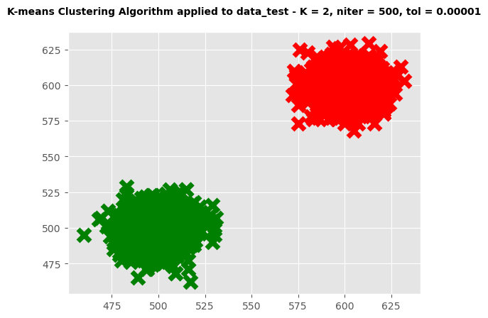

```python
# Boilerplate
import numpy as np
import matplotlib.pyplot as plt
from matplotlib import style

# let us define the style of the plot here
style.use('ggplot')
colors = ["g","r","c","b"]

# # sample data for this example
# p = np.array([[0.8922063, 0.26672425],[0.34475611, 0.35976697],[0.33253499, 0.18923898],[0.66872466, 0.46248986],[0.72823733, 0.10537784],[0.40903598, 0.70639412],[0.79926596, 0.90095583],[0.67886544, 0.84573289],[0.3641813, 0.64296743],[0.07461196, 0.74290527]])
# centroids = [np.array([0.46519213, 0.76779111]),np.array([0.59329188, 0.27671958])]
# clusters = np.array([1, 1, 1, 1, 1, 0, 0, 0, 0, 0])

# Set the seed for reproducibility purposes
np.random.seed(24)

# Apply the K-means algorithm to the data_test with K = 2, niter = 500 and tol = 0.00001
clusters, centroids = kmeans(data_test, K=2, niter=500, tol=0.00001)

# plot each point in the centroids array
for centroid in centroids:
    plt.scatter(centroid[0],centroid[1], marker="o", color="k", s=150, linewidths=5)

# plot each point in the points array, colored according to the cluster they belong
for i in range(len(clusters)):
    plt.scatter(data_test[i,0], data_test[i,1], marker="x", color=colors[int(clusters[i])], s=150, linewidths=5)

# Set the title of the plot [EXTRA]
plt.title("K-means Clustering Algorithm applied to data_test - K = 2, niter = 500, tol = 0.00001\n", fontsize=10, fontweight='bold')

# plot all elements
plt.show()
```

### Step 8

Write a function **inertia** that takes three input arguments: $points$, $clusters$, and $centroids$.  
Where $points$ is an 2-dimensional ndarray with the coordinates of each point in your dataset, clusters is a vector that indicates the cluster of each point (takes values between $0$ and $K-1$), and $centroids$ is a 2-dimensional ndarray with length $k$ of the coordinates of the centroids.

The function should return a tuple in which the first value is the number of clusters and the second is the computed **average squared distance** of the points to the centroid of the cluster they are assigned.

**Test your function and report the results of using point=p, clusters=c, and centroids=cen. These are the quantities that you computed above in the different steps**

```python
# Function to calculate the inertia of the K-means algorithm
def inertia(points: np.array, clusters: np.array, centroids: np.array):
    """Calculate the inertia of the K-means algorithm.

    Args:
        points (np.array): The data points.
        clusters (np.array): The cluster assigned to each point.
        centroids (np.array): The centroids of the clusters.

    Returns:
        number of clusters (int): The number of clusters.
        inertia (float): The inertia of the K-means algorithm.
    """

    # Initialize the inertia
    inertia = 0

    # Loop through each point
    for i in range(len(points)):
        # Calculate the distance between the point and the centroid of the cluster it belongs to
        squared_distance = distance(points[i], centroids[clusters[i]])**2

        # Update the inertia, summing the squared distance
        inertia += squared_distance

    # Calculate the average squared distance
    avg_squared_distance = inertia / len(points)

    # Return the number of clusters and the average squared distance
    return len(np.unique(clusters)), avg_squared_distance
```

```python
# Test the function with the test variables
K_example, avg_squared_distance_example = inertia(p, c, cen)
print("Number of clusters:", K_example,
      "\nAverage squared distance:", avg_squared_distance_example)
```

```
Number of clusters: 3
Average squared distance: 0.10954209828084607
```

> This means that with the given $3$ clusters and their corresponding centroids, the average squared distance of each point to its assigned cluster's centroid is approximately $0.1095$.

### Step 9

Load the data from file https://www.dropbox.com/s/wco3lxgn1f4a5k2/data_custering.csv?dl=1 into numpy array.  
The data consists of the coordinates of $N$ points in a 2-dimensional space.  
Use the functions **kmeans** and **internia** to identify the most suitable number of clusters.  
You might want to consider doing some visual inspection and reporting.  
For instance, inspect visually the dataset before performing the clustering; report the inertia values as a line plot; show the result of your clustering.

Tip: use the output of inertia to perform the elbow method https://en.wikipedia.org/wiki/Elbow_method_(clustering).

[figure not shown]

```python
# Load the data from the file into a numpy array
data_clustering = pd.read_csv("https://www.dropbox.com/s/wco3lxgn1f4a5k2/data_clustering.csv?dl=1").to_numpy()

# Check the shape of the data
print(data_clustering.shape)
```

```
(4999, 2)
```

```python
# Check the first 5 rows of the data
data_clustering[:5]
```

```
array([[665845, 557965],
       [597173, 575538],
       [618600, 551446],
       [635690, 608046],
       [588100, 557588]], dtype=int64)
```

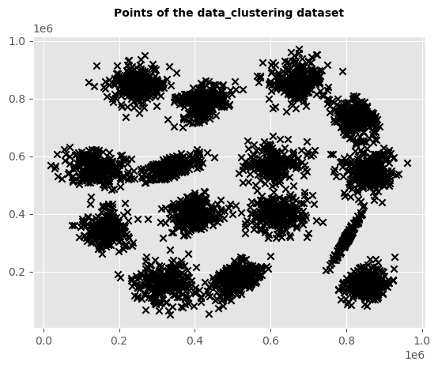

```python
# Plot the points into a scatter plot
plt.scatter(data_clustering[:, 0], data_clustering[:,1], color ='k', marker='x')
plt.title("Points of the data_clustering dataset\n", fontsize=10, fontweight='bold');
```

> While looking at the data we can imagine around $15$ clusters.

```python
# Initialize the number of clusters and the inertia values
clusters_values = []
inertia_values = []

# Loop through the number of clusters from 1 to 20 [We chose 20 clusters because it is a small dataset]
for K in range(1, 21):

    # Apply the K-means algorithm to the data_clustering with K clusters
    clusters, centroids = kmeans(data_clustering, K, 500, 0.00001)

    # Ensure clusters array contains integer values
    clusters = clusters.astype(int)

    # Calculate the inertia of the K-means algorithm
    num_clusters, avg_squared_distance = inertia(data_clustering, clusters, centroids)

    # Append the number of clusters and the inertia values to the lists
    clusters_values.append(num_clusters)
    inertia_values.append(avg_squared_distance)
```

```
Converged after 2 iterations
Converged after 5 iterations
Converged after 12 iterations
Converged after 16 iterations
Converged after 28 iterations
Converged after 23 iterations
Converged after 29 iterations
Converged after 9 iterations
Converged after 11 iterations
Converged after 19 iterations
Converged after 16 iterations
Converged after 11 iterations
Converged after 9 iterations
Converged after 8 iterations
Converged after 20 iterations
Converged after 31 iterations
Converged after 21 iterations
Converged after 34 iterations
Converged after 15 iterations
Converged after 17 iterations
```

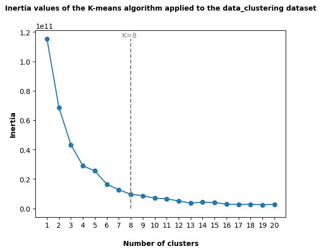

```python
# Plot the inertia values as a line plot
plt.style.use('default')  # Set the style of the plot
plt.plot(range(1, 21), inertia_values, marker='o')
plt.vlines(8, 0, max(inertia_values), colors='grey', linestyles='dashed')         # Add a vertical line at K=8
plt.text(8.5, max(inertia_values), "K=8", ha='right', va='bottom', color='grey')  # Add the text K=8
plt.title("Inertia values of the K-means algorithm applied to the data_clustering dataset\n", fontsize=10, fontweight='bold')
plt.xlabel("\nNumber of clusters", fontsize=10, fontweight='bold')
plt.ylabel("Inertia", fontsize=10, fontweight='bold')
plt.xticks(range(1, 21));
```

> According to the elbow plot the number $15$ is not the most appropriate number of clusters. While observing the plot, we can check that the line starts to become flat with **$k=8$**.

```python
# Implement the K-means algorithm with K = 8, niter = 500 and tol = 0.00001
clusters, centroids = kmeans(data_clustering, 8, 500, 0.00001)

# Check the number of clusters
print("Number of clusters:", len(np.unique(clusters)))

# Check the first 5 rows of the clusters and centroids
clusters[:5], centroids[:5]
```

```
Converged after 12 iterations
Number of clusters: 8
```

```
(array([4, 4, 4, 4, 4]),
 array([[380927.20193638, 485870.58921162],
        [326800.24233129, 818471.64877301],
        [848153.14534884, 162310.64825581],
        [153649.83553598, 454923.91189427],
        [784194.23474178, 616249.        ]]))
```

```python
# Check how many points are in each cluster
unique, counts = np.unique(clusters, return_counts=True)
dict(zip(unique, counts))
```

```
{0: 723, 1: 652, 2: 344, 3: 681, 4: 852, 5: 668, 6: 389, 7: 690}
```

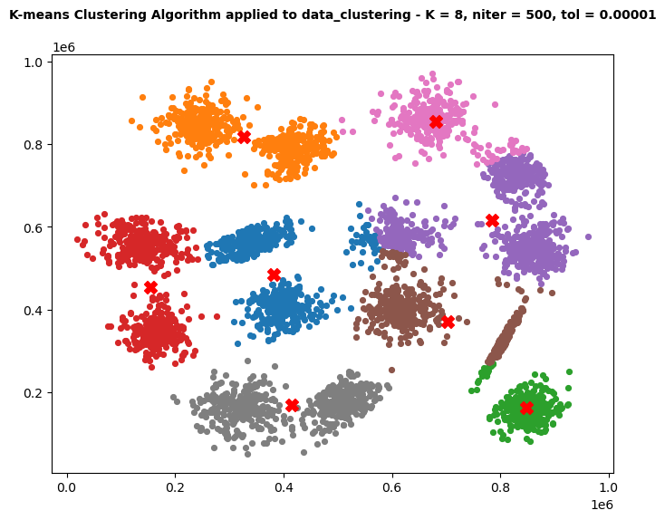

```python
# Plot the clusters and centroids into a scatter plot
plt.figure(figsize=(8, 6)) # Set the size of the plot

# Loop through each cluster to plot the points with different colors
for i in range(len(clusters)):
    plt.scatter(data_clustering[clusters == i, 0], # X values
                data_clustering[clusters == i, 1], # Y values
                color=plt.cm.tab10(i),             # Color of the points
                s=10, linewidth=2)                 # Size and width of the points

# Plot the centroids
plt.scatter(centroids[:, 0], centroids[:, 1],      # X and Y values of the centroids
            s=100, c='red', marker='X', label='Centroids') # Size, color, marker and label of the centroids

# Set the title and legend of the plot [EXTRA]
plt.title("K-means Clustering Algorithm applied to data_clustering - K = 8, niter = 500, tol = 0.00001\n", fontsize=10, fontweight='bold')
plt.show()
```

# **[EXTRA] - Implementing the Step 9 to the data generated by our function**

```python
# Testing data generated by our function - Implementing K-means Algorithm

# Initialize the number of clusters and the inertia values
clusters_values_gen = []
inertia_values_gen = []

# Loop through the number of clusters from 1 to 10
for K in range(1, 11):

    # Apply the K-means algorithm to the data with K clusters
    clusters, centroids = kmeans(data_gen, K, 500, 0.00001)

    # Calculate the inertia of the K-means algorithm
    num_clusters, avg_squared_distance = inertia(data_gen, clusters, centroids)

    # Append the number of clusters and the inertia values to the lists
    clusters_values_gen.append(num_clusters)
    inertia_values_gen.append(avg_squared_distance)
```

```
Converged after 2 iterations
Converged after 2 iterations
Converged after 4 iterations
Converged after 4 iterations
Converged after 5 iterations
Converged after 9 iterations
Converged after 12 iterations
Converged after 16 iterations
Converged after 15 iterations
Converged after 12 iterations
```

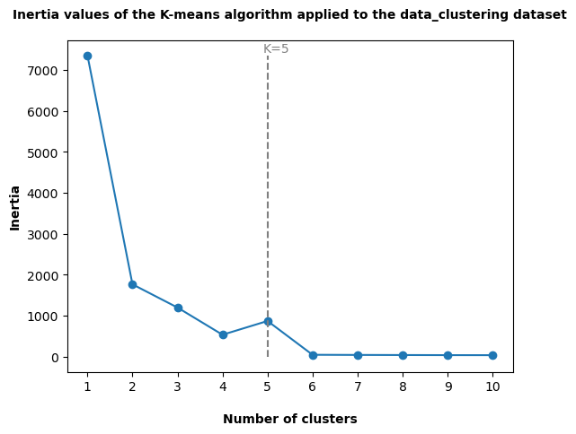

```python
# Plot the inertia values as a line plot
plt.plot(range(1, 11), inertia_values_gen, marker='o')
plt.vlines(5, 0, max(inertia_values_gen), colors='grey', linestyles='dashed')         # Add a vertical line at K=5
plt.text(5.5, max(inertia_values_gen), "K=5", ha='right', va='bottom', color='grey')  # Add the text K=5
plt.title("Inertia values of the K-means algorithm applied to the data_clustering dataset\n", fontsize=10, fontweight='bold')
plt.xlabel("\nNumber of clusters", fontsize=10, fontweight='bold')
plt.ylabel("Inertia", fontsize=10, fontweight='bold')
plt.xticks(range(1, 11));
```

```python
# Implement the K-means algorithm with K = 5, niter = 1_000_000_000 and tol = 1e-100
clusters_gen, centroids_gen = kmeans(data_gen, 5, 1_000_000_000, 1e-100)

# Check the number of clusters
print("Number of clusters:", len(np.unique(clusters_gen)))

# Check the first 5 rows of the clusters and centroids
clusters_gen[:5], centroids_gen[:5]
```

```
Converged after 2 iterations
Number of clusters: 5
```

```
(array([3, 3, 3, 3, 3]),
 array([[485.59516044, 640.01551363],
        [633.20470653, 491.32339679],
        [576.44409084, 642.78092324],
        [585.5717194 , 546.06263628],
        [578.11442915, 476.70576276]]))
```

```python
# Check how many points are in each cluster
unique, counts = np.unique(clusters_gen, return_counts=True)
dict(zip(unique, counts))
```

```
{0: 200, 1: 200, 2: 200, 3: 200, 4: 200}
```

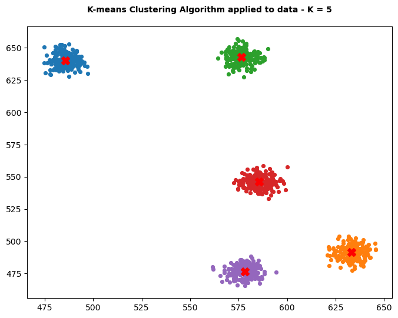

```python
# Plot the clusters and centroids into a scatter plot
plt.style.use('default')    # Set the style of the plot
plt.figure(figsize=(8, 6))  # Set the size of the plot

for i in range(len(clusters_gen)):
    plt.scatter(data_gen[clusters_gen == i, 0], # X values
                data_gen[clusters_gen == i, 1], # Y values
                color=plt.cm.tab10(i),             # Color of the points
                s=10, linewidth=2)                 # Size and width of the points

# Plot the centroids
plt.scatter(centroids_gen[:, 0], centroids_gen[:, 1],      # X and Y values of the centroids
            s=100, c='red', marker='X', label='Centroids') # Size, color, marker and label of the centroids

# Set the title and legend of the plot
plt.title("K-means Clustering Algorithm applied to data - K = 5\n", fontsize=10, fontweight='bold')
plt.show()
```

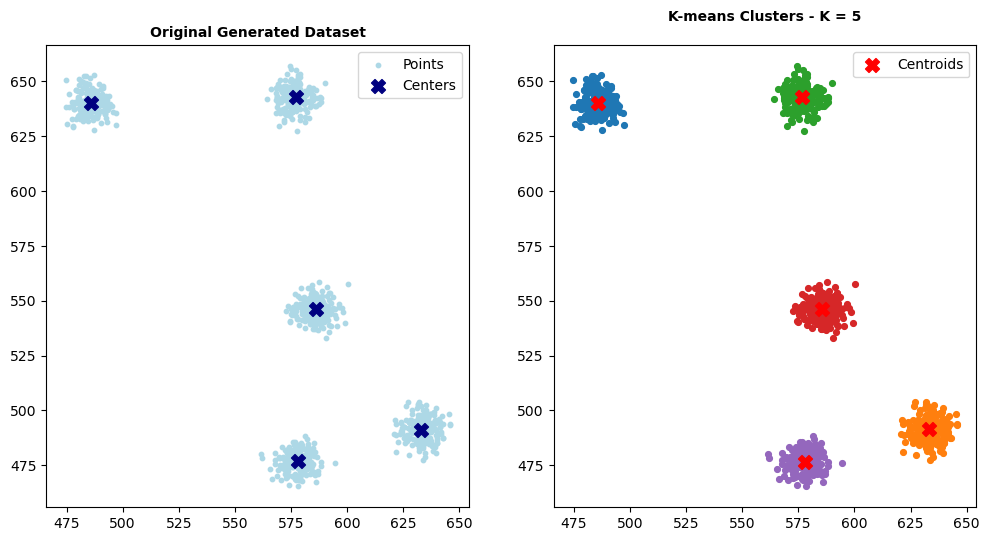

```python
# Compare the clusters and centroids with the generated data - 2 subplots
fig, axs = plt.subplots(1, 2, figsize=(12, 6))

# ------------- [Original Clusters] -------------
# Plot the original clusters and centroids
axs[0].scatter(data_gen[:, 0], data_gen[:,1], c='lightblue', label='Points', s=10)
axs[0].scatter(centers_gen[:, 0], centers_gen[:,1], c='navy', s=100, marker='X', label='Centers')
axs[0].set_title("Original Generated Dataset", fontsize=10, fontweight='bold')
axs[0].legend()

# ------------- [K-means Clusters] -------------
# Plot the clusters and centroids made by the K-means algorithm
for i in range(len(clusters_gen)):
    axs[1].scatter(data_gen[clusters_gen == i, 0],     # X values
                data_gen[clusters_gen == i, 1],        # Y values
                color=plt.cm.tab10(i),                 # Color of the points
                s=10, linewidth=2)                     # Size and width of the points

# Plot the centroids
axs[1].scatter(centroids_gen[:, 0], centroids_gen[:, 1],           # X and Y values of the centroids
            s=100, c='red', marker='X', label='Centroids')         # Size, color, marker and label of the centroids

# Set the title and legend of the plot
axs[1].set_title("K-means Clusters - K = 5\n", fontsize=10, fontweight='bold')
axs[1].legend()
plt.show()
```